# Lab2

Author

Harshini Karthikeyan

Published

Invalid Date

# Lab 2

```r
library(tidyverse)
library(dplyr)
library(ggplot2)
library(readxl)
library(ggrepel)

library(scales)
```

## Part 1:

2. List the variables that appear to be displayed in this visualization. *Hint: Variables refer to columns in the data.*

The country, the global region of the country and the percentage of people in the country that believe a vaccine is safe.

3. Now that you’re versed in the grammar of graphics (e.g., `ggplot`), list the *aesthetics* used and which *variables* are mapped to each.

The x-axis the percentage of people in the country that believe a vaccine is safe. The y-axis is the country, the color is filled by global region.

4. What type of graph would you call this? Meaning, what `geom` would you use to produce this plot?

I would call this a scatter plot and would use geom point to produce it.

5. Provide at least four problems or changes that would improve this graph. *Please format your changes as bullet points!*
- I think this is a graph that is faceted by region of the world, but it lends to a strange stacked graph like view that is not very intuitive, and leaves some plots stranded from their axes. I would try faceting differently or trying to remove the facet entirely.
- I think having the y-axis be the countries is a bit strange, and that sorting it by the proportion feels odd, as though it is increasing over time or something, I would try sorting it alphabetically or removing the y-axis and making it a box-plot instead.
- I think having the legend at the bottom is unnecessary as the global region is also written directly onto each facet of the plot, so I would remove one of those, preferably the legend, depending on how my plot turns out.
- I think having to state that the dark vertical lines represent region medians but also not writing the number of each on the plot itself is confusing and forces the reader to then look for th median by finding the axis

## **Improving the Bad Visualization**

```r
data<-read_excel("C:\\Users\\Geetha\\Downloads\\wgm2018-dataset-crosstabs-all-countries.xlsx")
head(data)
```

```
# A tibble: 6 × 45
  ...1        ...2       ...3  `National results` ...5  Gender ...7  ...8  ...9
  <chr>       <chr>      <chr> <chr>              <chr> <chr>  <chr> <chr> <chr>
1 <NA>        <NA>       <NA>  Country total      <NA>  Male   <NA>  Fema… <NA>
2 Country     Question   Resp… Column N %         Unwe… Colum… Unwe… Colu… Unwe…
3 Afghanistan Q1 How mu… A lot 2.456111760451949… 30    4.523… 23    4.40… 7
4 Afghanistan <NA>       Some  0.337138465643189… 393   0.416… 230   0.25… 163
5 Afghanistan <NA>       Not … 0.309526616406561… 287   0.347… 170   0.27… 117
6 Afghanistan <NA>       Noth… 0.292750581876620… 257   0.188… 75    0.39… 182
# ℹ 36 more variables: `Age Cohort` <chr>, ...11 <chr>, ...12 <chr>,
#   ...13 <chr>, ...14 <chr>, ...15 <chr>,
#   `General Educational Background` <chr>, ...17 <chr>, ...18 <chr>,
#   ...19 <chr>, ...20 <chr>, ...21 <chr>, `Area Type` <chr>, ...23 <chr>,
#   ...24 <chr>, ...25 <chr>, `Identifies with Specific Religion` <chr>,
#   ...27 <chr>, ...28 <chr>, ...29 <chr>, `Per Capita Income Quintile` <chr>,
#   ...31 <chr>, ...32 <chr>, ...33 <chr>, ...34 <chr>, ...35 <chr>, …
```

```r
national <- data[c('...1', '...2', '...3', 'National results','...5')]
colnames(national) <- c("Country", "Question", "Response", "National_Results_Col_Per", "National_Results_Count")

national <- national[!(national$Country %in% c(NA, 'Country')),]
#drop title row since renamed cols alr
```

```r
national$QNumber <- str_split_i(national$Question, " ", 1)
national
```

```
# A tibble: 35,845 × 6
   Country     Question   Response National_Results_Col…¹ National_Results_Count
   <chr>       <chr>      <chr>    <chr>                  <chr>
 1 Afghanistan "Q1 How m… A lot    2.4561117604519497E-2  30
 2 Afghanistan  <NA>      Some     0.33713846564318944    393
 3 Afghanistan  <NA>      Not much 0.30952661640656171    287
 4 Afghanistan  <NA>      Nothing… 0.29275058187662067    257
 5 Afghanistan  <NA>      (DK)     3.6023218469106791E-2  33
 6 Afghanistan  <NA>      Total    1                      1000
 7 Afghanistan "Q2 How m… All of … 1.9034573690898671E-2  21
 8 Afghanistan  <NA>      Some of… 0.38102335826789896    428
 9 Afghanistan  <NA>      Not muc… 0.30997405231133479    305
10 Afghanistan  <NA>      None of… 0.24654838910650081    208
# ℹ 35,835 more rows
# ℹ abbreviated name: ¹National_Results_Col_Per
# ℹ 1 more variable: QNumber <chr>
```

```r
asia <- c('Afghanistan', 'Bangladesh', 'Cambodia', 'China', 'India', 'Indonesia', 'Japan', 'Laos', 'Malaysia', 'Mongolia', 'Myanmar', 'Nepal', 'Pakistan', 'Philippines', 'Singapore', 'South Korea', 'Sri Lanka', 'Taiwan', 'Thailand', 'Vietnam'
)

mena <- c('Algeria', 'Egypt', 'Iran', 'Iraq', 'Israel', 'Jordan', 'Kuwait', 'Lebanon','Libya', 'Morocco', 'Palestine', 'Saudi Arabia', 'Tunisia', 'United Arab Emirates', 'Yemen'
)

americas <- c('Argentina', 'Bolivia', 'Brazil', 'Canada', 'Chile', 'Colombia', 'Costa Rica', 'Dominican Republic', 'Ecuador', 'El Salvador', 'Guatemala', 'Haiti', 'Honduras','Mexico', 'Nicaragua', 'Panama', 'Paraguay', 'Peru', 'United States', 'Uruguay', 'Venezuela'
)

sub_sahara <- c('Benin', 'Botswana', 'Burkina Faso', 'Burundi', 'Cameroon', 'Congo, Rep.','Comoros', 'Chad','Eswatini','Ethiopia', 'Gabon', 'Ghana', 'Guinea', 'Ivory Coast', 'Kenya', 'Liberia', 'Madagascar', 'Malawi', 'Mali', 'Mauritania', 'Mauritius','Mozambique', 'Namibia', 'Niger', 'Nigeria', 'Rwanda', 'Senegal','Sierra Leone', 'South Africa', 'Tanzania', 'The Gambia', 'Togo','Uganda', 'Zambia', 'Zimbabwe'
)

europe <- c('Albania', 'Austria', 'Belgium', 'Bosnia and Herzegovina', 'Bulgaria','Croatia', 'Cyprus', 'Czech Republic', 'Denmark', 'Finland', 'France','Germany', 'Greece', 'Hungary', 'Iceland', 'Ireland', 'Italy', 'Kosovo','Luxembourg', 'Macedonia', 'Malta', 'Netherlands', 'Norway', 'Poland', 'Northern Cyprus', 'Montenegro', 'Portugal', 'Romania', 'Serbia', 'Slovakia', 'Slovenia', 'Spain', 'Sweden', 'Switzerland', 'Turkey', 'United Kingdom'
)

former_soviet <- c('Armenia', 'Azerbaijan', 'Belarus', 'Estonia', 'Georgia', 'Kazakhstan', 'Kyrgyzstan', 'Latvia', 'Lithuania', 'Moldova', 'Russia', 'Tajikistan', 'Ukraine', 'Uzbekistan', 'Turkmenistan'
)

oceania <- c('Australia', 'New Zealand')
```

```r
national1 <- national |>
  fill(QNumber, .direction = "down") |>
  #Source for .direction: https://tidyr.tidyverse.org/reference/fill.html
  filter(QNumber == "Q25") |>
  filter(Response == "Strongly agree" | Response == "Somewhat agree") |> group_by(Country) |>
  summarize(Agree_Percent = sum(as.numeric(National_Results_Col_Per)), .groups = "drop") |> mutate(Region = case_when(

    Country %in% asia ~ "Asia",
    Country %in% mena ~ "Middle East and North Africa",
    Country %in% americas ~ "Americas",
     Country %in% sub_sahara ~ "Sub-Saharan Africa",
    Country %in% europe ~ "Europe",

    Country %in% former_soviet ~ "Former Soviet Union",

    Country %in% oceania ~ "Oceania",

    TRUE ~ "Other" #used to check, there are none that fall in this category
  ))
  #summarize function : https://stackoverflow.com/questions/62891736/sum-sub-groups-with-dplyr
```

```r
outliers <- national1|>
  group_by(Region)|>
  mutate(
    Q1 = quantile(Agree_Percent, 0.25),  Q3 = quantile(Agree_Percent, 0.75),
    IQR = Q3 - Q1,
    is_outlier = Agree_Percent < (Q1 - 1.5 * IQR) | Agree_Percent > (Q3 + 1.5 * IQR)
  ) |>
  filter(is_outlier)
```

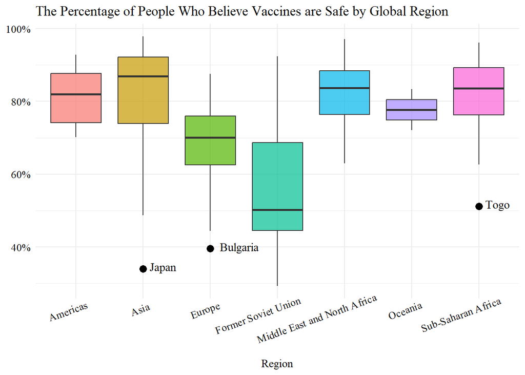

```r
ggplot(national1, aes(x = Region,y=Agree_Percent,fill = Region))+
  geom_boxplot(outlier.shape= NA,alpha = 0.7) +
  geom_point(data = outliers, aes(x =Region, y= Agree_Percent), shape =16, size =3, color = "black") +
  geom_text(
    data =outliers,
    aes(label= Country), vjust =0.25, hjust=-0.25,  size = 4, family="serif"
  )+ scale_y_continuous(labels = percent_format(accuracy = 1)) +
  labs(
    title = "The Percentage of People Who Believe Vaccines are Safe by Global Region",
    x= "Region",y= NULL,
  ) +theme_minimal(base_family = "serif")+

  theme(axis.text.x = element_text(angle = 20, hjust = 0.75), axis.text = element_text(size = 10,color = "black"), legend.position = "none"
        )
```